# Assignment 6: ANCOVA HW

Leandro Ledesma

2024-10-16

### Load in the data

Description: This fictional data set, “Viagra”, provides men’s libido (and that of their partners) after having been administered different doses of viagra. Variables:

- dose - Viagra dosage administered (Placebo, Low Dose, High Dose).
- libido - Participant’s libido (measured over the course of one week).
- partnerLibido - Libido of participant’s partner (measured over the course of one week).

### Examine the data

1. What are the factor(s) in this example and How many levels (J) does each factor have?
- There is one factor that represents the dosage of Viagra taken. It includes three levels (Placebo, Low Dose, High Dose).
2. What is the dependent variable in this example?
- The outcome variable is the participant’s libido.
3. What is the covariate in this example?
- The covariate is the libido of the partner’s libido
4. Examine and briefly report relevant descriptive statistics, including measures of central tendency, variability, normality, and/or counts for each independent and dependent variable. Include your code and results.
- There are three levels to Viagra dosage with 9 subjects getting a placebo pill (30%), 8 getting a low dosage (27%), and 13 getting a high dosage (43%). The libido variable (outcome) is numeric and has a mean of 4.3 (median = 4) with a standard deviation of 1.96 (var = 3.83). The distribution of these scores is skewed to the right, indicating that most people tended to have libidos below the mean of the outcome. Partner’s Libido also has a right skewed distribution, which also shows that most partner’s libido was also lower than the average (mean = 2.73, sd = 1.86).
5. Check and report the correlations among predictors. Is multicollinearity an issue?
- Since the levels of the factor are ordinal (Placebo, Low Dose, High Dose), we can keep them as “numeric” variables that are ranked and correlate them to the covariate using Spearman’s Rank Correlation. The correlation coefficient indicates no multicollinearity between the predictors because the correlation is not that strong (r = -0.32)

```r
# Use the glimpse function to understand the data better
glimpse(data)
```

```
Rows: 30
Columns: 3
$ dose          <int> 1, 1, 1, 1, 1, 1, 1, 1, 1, 2, 2, 2, 2, 2, 2, 2, 2, 3, 3,…
$ libido        <int> 3, 2, 5, 2, 2, 2, 7, 2, 4, 7, 5, 3, 4, 4, 7, 5, 4, 9, 2,…
$ partnerLibido <int> 4, 1, 5, 1, 2, 2, 7, 4, 5, 5, 3, 1, 2, 2, 6, 4, 2, 1, 3,…
```

```r
# Convert libido into a factor
data$dose <- as.factor(data$dose)

# Obtain the frequency of each level of the factor
table(data$dose)
```

```
 1  2  3
 9  8 13
```

```r
# Get some descriptives of the numeric variables
describe(data$libido)
```

```
   vars  n mean   sd median trimmed  mad min max range skew kurtosis   se
X1    1 30 4.37 1.96      4    4.21 2.22   2   9     7 0.51    -0.65 0.36
```

```r
describe(data$partnerLibido)
```

```
   vars  n mean   sd median trimmed  mad min max range skew kurtosis   se
X1    1 30 2.73 1.86    2.5    2.67 2.22   0   7     7 0.38    -0.79 0.34
```

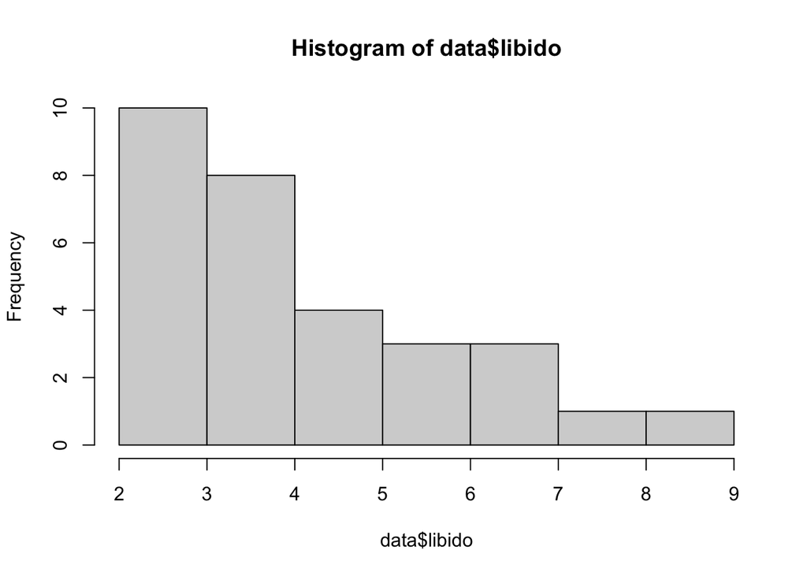

```r
hist(data$libido)
```

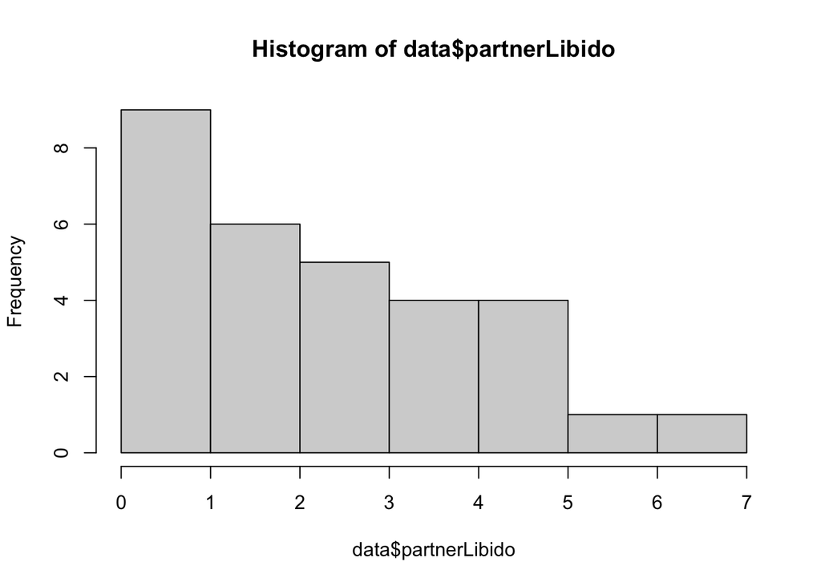

```r
hist(data$partnerLibido)
```

```r
# Correlate Libido and partner libido
cor(as.numeric(data$dose), data$partnerLibido, method = "spearman")
```

```
[1] -0.3237866
```

### Hypotheses

6. Write the null hypotheses as they relate to the population means.
- $H_{0} : \mu_{1} = \mu_{2} = \mu_{3}$ (At the adjusted means)
7. Write the alternative hypotheses as they relate to the population means.
- $H_{A}:\mu_{j}\neq\mu_{k}$ (At the adjusted means)
8. Using typical language, write the null hypothesis.
- Viagra dosage has no effect on a participant’s libido no matter what their partner’s libido is.
9. Using typical language, write the alternative hypothesis.
- Viagra dosage does have an effect on a participant’s libido at any level of their partner’s libido.

### Fit ANCOVA & Compare Models (10 pts)

10. Fit the following models using Type I SS.
1. An empty model
2. A model that includes only the covariate effects on the outcome.
3. A model that includes covariate and main effects on the outcome.
4. A model that includes covariate, main, and interaction effects.
11. Report your code and output.
12. Using model outputs, compare the fit among models. Report your code and output.
13. Based on your comparison, which model should you choose to interpret?
- Using the Anova() function to compare the different models, the best one to interpret is the full model with the inclusion of the covariate, the main effects, and their interaction. This is because when building the model using Type I SS, the full model had a significantly smaller residual SS than the previous model without the interaction (p < .05).
14. Report the selected ANCOVA Table of Results, including all relevant SS, df, MS, F, and p values. You can use R or create a table by hand. Report in APA style.
- Two output tables were created- both saying the same information. I prefer the table that looks like a regression but to not lose points I am showing both. I used the APA Tables from https://apastyle.apa.org/style-grammar-guidelines/tables-figures/sample-tables to help me create these.

```r
# Convert dose into a factor
data$dose <- factor(data$dose)

# Check the contrasts of the main effect
contrasts(data$dose)
```

```
  2 3
1 0 0
2 1 0
3 0 1
```

```r
# Create an empty model
empty.model <- lm(libido ~ 1,data)

# Create a model that includes only the covariate
covariateOnly.model <- lm(libido ~ partnerLibido, data)

# Create a model that includes only the main effect (for Levene's Test)
MainOnly <- lm(libido ~ dose, data)

# Create a model that includes the covariate and main effects
covariateMain.model <- lm(libido ~ partnerLibido + dose, data)

# Create a model with the covariate, main effects, and interaction
full.model <- lm(libido ~ partnerLibido * dose, data)
full.model.aov <- aov(libido ~ partnerLibido * dose, data)

# Compare the fit for these models (Type 1 SS)
anova(empty.model, covariateOnly.model, covariateMain.model, full.model)
```

```
Analysis of Variance Table

Model 1: libido ~ 1
Model 2: libido ~ partnerLibido
Model 3: libido ~ partnerLibido + dose
Model 4: libido ~ partnerLibido * dose
  Res.Df     RSS Df Sum of Sq      F  Pr(>F)
1     29 110.967
2     28 104.232  1    6.7344 2.7571 0.10983
3     26  79.047  2   25.1852 5.1556 0.01372 *
4     24  58.621  2   20.4266 4.1815 0.02767 *
---
Signif. codes:  0 '***' 0.001 '**' 0.01 '*' 0.05 '.' 0.1 ' ' 1
```

```r
# Convert the summary of the regression into a dataset
full.model.sum_df <- broom::tidy(summary(full.model))
full.model.aov.sum_df <- broom::tidy(full.model.aov)

# Round the output
full.model.sum_df <- full.model.sum_df %>%
  mutate_at(c("estimate", "std.error", "statistic", "p.value"), ~round(.,2))

full.model.aov.sum_df <- full.model.aov.sum_df %>%
  mutate_at(c("df", "sumsq", "meansq", "statistic", "p.value"), ~round(.,2))

# Rename the variables
names(full.model.sum_df) <- c("Effect", "Estimate", "SE", "t", "p")
names(full.model.aov.sum_df) <- c("Source", "df","SS","MS", "F","p")

# Rename the rows
full.model.sum_df$Effect <- c("Intercept", "Partner's Libido",
                                  "No Dose vs Low Dose",
                                  "No Dose vs High Dose",
                                  "Parner's Libido x Low Dose",
                                  "Partner's Libido x High Dose")

full.model.aov.sum_df$Source <- c("Partner's Libido",
                                  "Viagra Dosage",
                                  "Parner's Libido x Viagra Dosage",
                                  "Residuals")

# Print the table
full.model.aov.sum_df %>%
  kbl(caption = "ANCOVA Summary Table") %>%
  kable_classic(full_width = F, html_font = "Cambria")
```

ANCOVA Summary Table

| Source | df | SS | MS | F | p |
| --- | --- | --- | --- | --- | --- |
| Partner’s Libido | 1 | 6.73 | 6.73 | 2.76 | 0.11 |
| Viagra Dosage | 2 | 25.19 | 12.59 | 5.16 | 0.01 |
| Parner’s Libido x Viagra Dosage | 2 | 20.43 | 10.21 | 4.18 | 0.03 |
| Residuals | 24 | 58.62 | 2.44 | NA | NA |

```r
full.model.sum_df %>%
  kbl(caption = "Regression Summary Table") %>%
  kable_classic(full_width = F, html_font = "Cambria") %>%
  footnote("F-statistic: 4.286 on 5 and 24 DF,  p-value: 0.006295")
```

Regression Summary Table

| Effect | Estimate | SE | t | p |
| --- | --- | --- | --- | --- |
| Intercept | 0.59 | 1.06 | 0.56 | 0.58 |
| Partner’s Libido | 0.76 | 0.27 | 2.86 | 0.01 |
| No Dose vs Low Dose | 1.72 | 1.60 | 1.07 | 0.29 |
| No Dose vs High Dose | 4.69 | 1.27 | 3.69 | 0.00 |
| Parner’s Libido x Low Dose | 0.06 | 0.43 | 0.13 | 0.90 |
| Partner’s Libido x High Dose | -0.98 | 0.38 | -2.55 | 0.02 |

Note:  
F-statistic: 4.286 on 5 and 24 DF, p-value: 0.006295

### Assumption Check (10 pts).

15. List all assumptions of ANCOVA.
- Independent observations: We cannot have the same participant’s data more than once when the data is in wide format.
- Normality of residuals: The residuals of the model need to look normally distributed.
- Homogeneity of variance: The variance of each level of the factor must be similar to each other.
- Linearity between Covariate and Outcome: There needs to be a linear relationship between the covariate and outcome variable.
- No multicollinearity: There must not be a strong relationship between the covariate and the predictor
- Random Sampling: The subjects recruited into the study were sampled randomly.
16. Check all assumptions of ANCOVA and report your logic/results.
- Independent observations: We are assuming the observations each belong to a different person. It is difficult to confirm since there is no ID variable in the dataset.
- Normality of residuals: The histogram and QQplot of the residuals visually look normally distributed. It also has a p value greater than .05 in the Shapiro-Wilk test, which further supports the errors are normally distributed.
- Homogeneity of variance: Visualization using box plots of the variance of the outcome for each of the three levels looks similar. Running Levene’s test (p= ns) and the Breush-Pagan test (p=ns) also indicate that the variance of the levels are similar to each other.
- Linearity Between Covariate and Outcome: This can be identified visually by creating a scatterplot with regression lines going through the dots of each respective group (level of the factor). This was done for the plot in Q17 and it looks like this assumption was met.
- No multicollinearity: We assessed this in the beginning and found no multicollinearity
- Random Sampling: We are assuming the data were sampled at random.

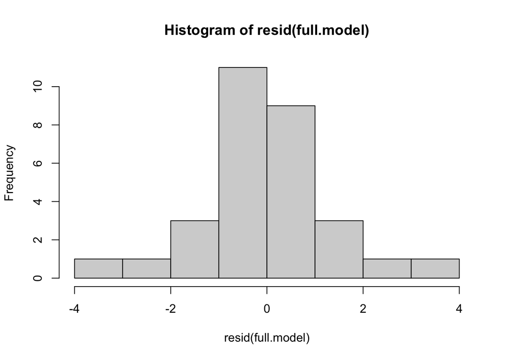

```r
# Check for independence of observations
hist(resid(full.model))
```

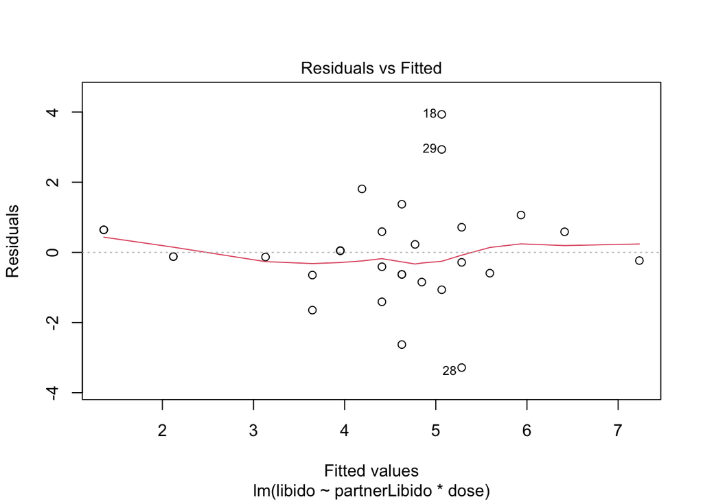

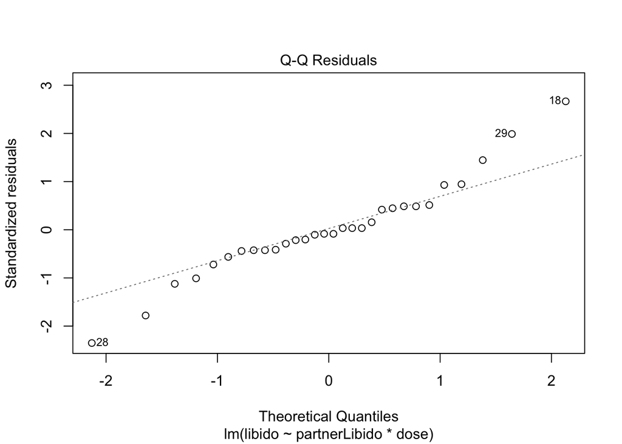

```r
plot(full.model, which = c(1, 2)) # the first and second plot
```

```r
shapiro.test(resid(full.model))
```

```
    Shapiro-Wilk normality test

data:  resid(full.model)
W = 0.94754, p-value = 0.1453
```

```r
leveneTest(MainOnly, center = median)
```

```
Levene's Test for Homogeneity of Variance (center = median)
      Df F value Pr(>F)
group  2  0.3256 0.7249
      27
```

```r
bptest(MainOnly)
```

```
    studentized Breusch-Pagan test

data:  MainOnly
BP = 1.5054, df = 2, p-value = 0.4711
```

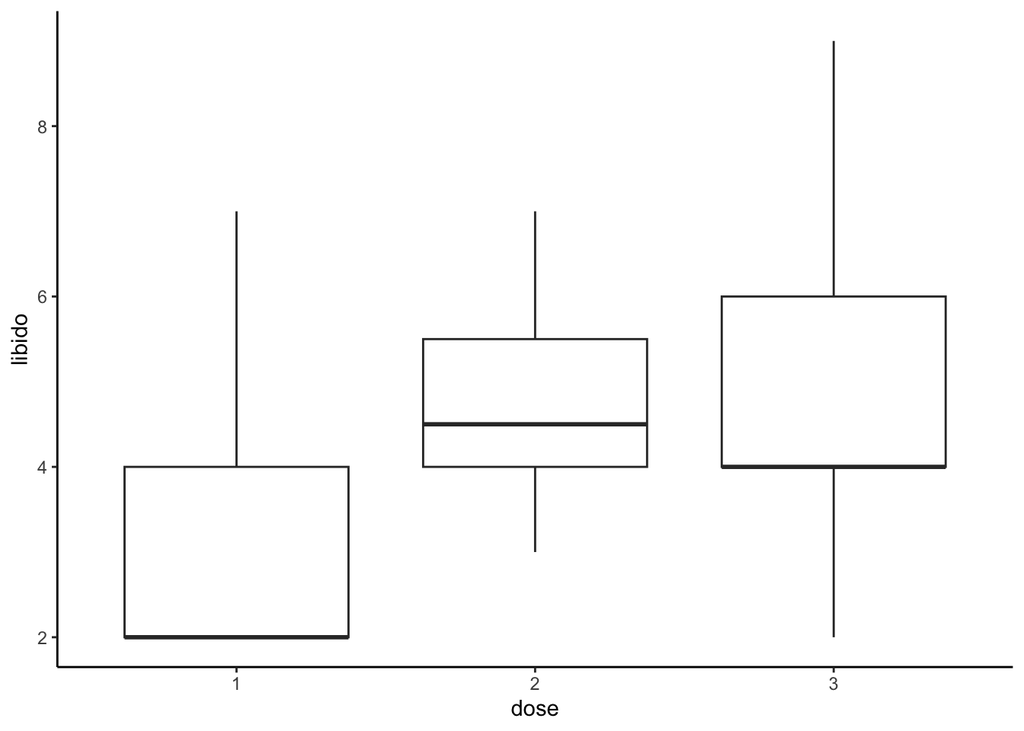

```r
data %>%
ggplot(aes(x = dose, y = libido)) +
  geom_boxplot() +
  theme_classic()
```

### Figure of Results (5 pts)

17. Create a figure to show the results of the final model.

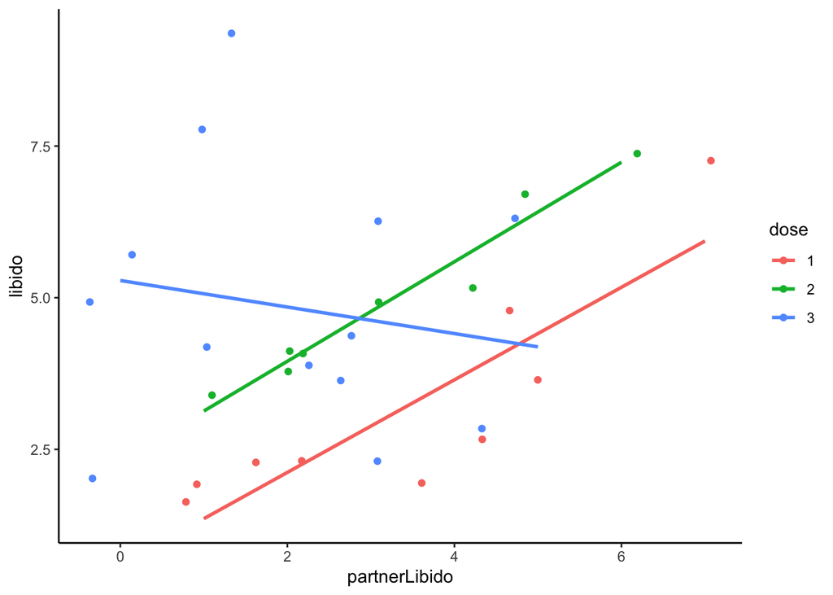

```r
data %>%
ggplot(aes(x = partnerLibido, y = libido, color = dose)) +
  geom_jitter() +
  geom_smooth(method = "lm", se = F) +
  theme_classic()
```